# Linear regression

aeroshev

### Load modules

```r
library(pacman)
p_load(rio, dplyr, hexbin, RColorBrewer, ggplot2)
```

# Load anf prepair data

### Load data

```r
df <- as.data.frame(import("./zeta.csv"))
df <- transform(df,
          meanage=as.numeric(meanage),
          meaneducation=as.numeric(meaneducation),
          meanhouseholdincome=as.numeric(meanhouseholdincome))
head(df)
```

|  | V1 | zcta | sex | meanage | meaneducation | meanemployment | meanhouseholdincome |
| --- | --- | --- | --- | --- | --- | --- | --- |
| 1 | 1 | 602 | F | 37.40335 | 10.912822 | 0.7400294 | 18533.84 |
| 2 | 2 | 602 | M | 35.93574 | 10.692618 | 1.3438833 | 18533.84 |
| 3 | 3 | 604 | F | 31.80943 | 13.913371 | 1.0858555 | 40784.49 |
| 4 | 4 | 604 | M | 31.10425 | 14.264654 | 1.6025594 | 40784.49 |
| 5 | 5 | 606 | F | 35.99079 | 10.097773 | 0.6287526 | 17496.53 |
| 6 | 6 | 606 | M | 35.99027 | 9.927995 | 1.2169643 | 17496.53 |

### Remove duplicates “meanhouseholdincome”

```r
df <- df %>% distinct(meanhouseholdincome, .keep_all=TRUE)
head(df)
```

|  | V1 | zcta | sex | meanage | meaneducation | meanemployment | meanhouseholdincome |
| --- | --- | --- | --- | --- | --- | --- | --- |
| 1 | 1 | 602 | F | 37.40335 | 10.91282 | 0.7400294 | 18533.84 |
| 2 | 3 | 604 | F | 31.80943 | 13.91337 | 1.0858555 | 40784.49 |
| 3 | 5 | 606 | F | 35.99079 | 10.09777 | 0.6287526 | 17496.53 |
| 4 | 7 | 610 | F | 37.26014 | 10.96916 | 0.8543247 | 19416.41 |
| 5 | 9 | 612 | F | 40.42732 | 11.57577 | 0.7815393 | 21607.34 |
| 6 | 11 | 616 | F | 38.24761 | 10.99235 | 0.7437151 | 17243.75 |

### Remove columns “zcta” and “sex”

```r
df <- within(df, rm(V1, zcta, sex))
head(df)
```

|  | meanage | meaneducation | meanemployment | meanhouseholdincome |
| --- | --- | --- | --- | --- |
| 1 | 37.40335 | 10.91282 | 0.7400294 | 18533.84 |
| 2 | 31.80943 | 13.91337 | 1.0858555 | 40784.49 |
| 3 | 35.99079 | 10.09777 | 0.6287526 | 17496.53 |
| 4 | 37.26014 | 10.96916 | 0.8543247 | 19416.41 |
| 5 | 40.42732 | 11.57577 | 0.7815393 | 21607.34 |
| 6 | 38.24761 | 10.99235 | 0.7437151 | 17243.75 |

### Remove outliers

```r
df <- df %>% filter(between(meaneducation, 8, 18)) %>%
             filter(between(meanhouseholdincome, 10000, 200000)) %>%
             filter(between(meanemployment, 0, 3)) %>%
             filter(between(meanage, 20, 60))
head(df)
```

|  | meanage | meaneducation | meanemployment | meanhouseholdincome |
| --- | --- | --- | --- | --- |
| 1 | 37.40335 | 10.91282 | 0.7400294 | 18533.84 |
| 2 | 31.80943 | 13.91337 | 1.0858555 | 40784.49 |
| 3 | 35.99079 | 10.09777 | 0.6287526 | 17496.53 |
| 4 | 37.26014 | 10.96916 | 0.8543247 | 19416.41 |
| 5 | 40.42732 | 11.57577 | 0.7815393 | 21607.34 |
| 6 | 38.24761 | 10.99235 | 0.7437151 | 17243.75 |

### Create a new variable

```r
df <- cbind(df, log10(df$meanhouseholdincome))
head(df)
```

|  | meanage | meaneducation | meanemployment | meanhouseholdincome | log10(df$meanhouseholdincome) |
| --- | --- | --- | --- | --- | --- |
| 1 | 37.40335 | 10.91282 | 0.7400294 | 18533.84 | 4.267966 |
| 2 | 31.80943 | 13.91337 | 1.0858555 | 40784.49 | 4.610495 |
| 3 | 35.99079 | 10.09777 | 0.6287526 | 17496.53 | 4.242952 |
| 4 | 37.26014 | 10.96916 | 0.8543247 | 19416.41 | 4.288169 |
| 5 | 40.42732 | 11.57577 | 0.7815393 | 21607.34 | 4.334601 |
| 6 | 38.24761 | 10.99235 | 0.7437151 | 17243.75 | 4.236632 |

### Reaname columns

```r
colnames(df) <- c("age", "education", "employment", "income", "log_income")
head(df)
```

|  | age | education | employment | income | log_income |
| --- | --- | --- | --- | --- | --- |
| 1 | 37.40335 | 10.91282 | 0.7400294 | 18533.84 | 4.267966 |
| 2 | 31.80943 | 13.91337 | 1.0858555 | 40784.49 | 4.610495 |
| 3 | 35.99079 | 10.09777 | 0.6287526 | 17496.53 | 4.242952 |
| 4 | 37.26014 | 10.96916 | 0.8543247 | 19416.41 | 4.288169 |
| 5 | 40.42732 | 11.57577 | 0.7815393 | 21607.34 | 4.334601 |
| 6 | 38.24761 | 10.99235 | 0.7437151 | 17243.75 | 4.236632 |

# Analysis

`a.` ## We will be analyzing this data with income as the dependent variable and the other columns as independent variables.  
Create a scatter plot showing the effect age has on log_income and paste it here.  
Do you see any linear relationship between the two variables?  
### Simple plot

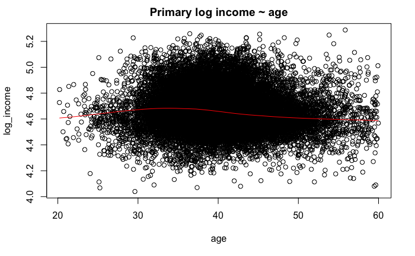

```r
plot(df$log_income ~ df$age,
     ylab="log_income",
     xlab="age",
     main="Primary log income ~ age",)
with(df, lines(loess.smooth(age, log_income), col="red"))
```

### Pretty plot

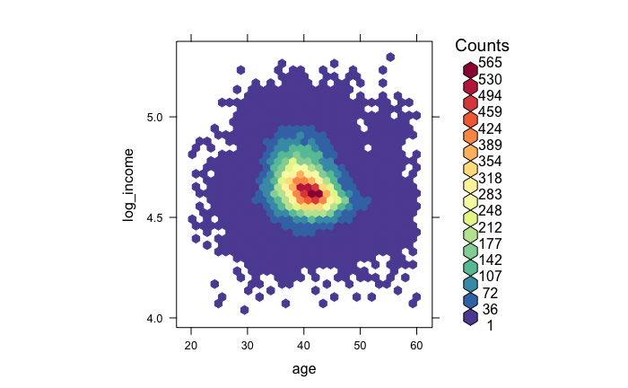

```r
opacity <- colorRampPalette(rev(brewer.pal(11,'Spectral')))
hexbinplot(df$log_income ~ df$age,
           ylab="log_income",
           xlab="age",
           colramp=opacity)
```

### Plot with prediction

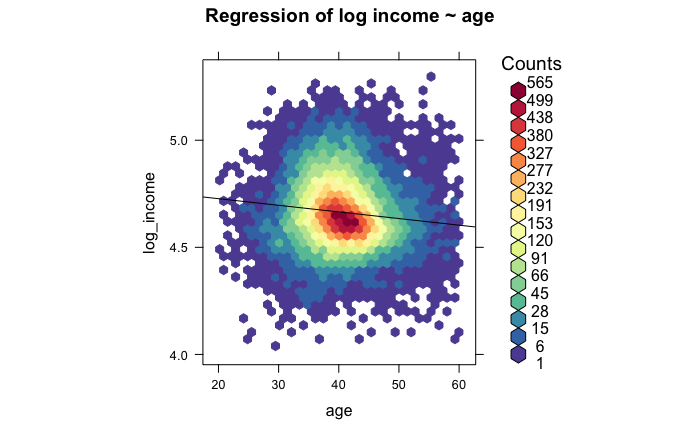

```r
hexbinplot(df$log_income ~ df$age,
           trans=sqrt,
           inv=function(x) x^2,
           type=c("r"),
           ylab="log_income",
           xlab="age",
           main="Regression of log income ~ age",
           colramp=opacity)
```

### Create a linear regression

`b.` Create a linear regression model between log_income and age. What is the interpretation of the t-value? What kind of t-value would indicate a significant coefficient?

```r
model_age <- lm(formula=log_income ~ age, data=df)
summary(model_age)
```

```
Call:
lm(formula = log_income ~ age, data = df)

Residuals:
     Min       1Q   Median       3Q      Max
-0.65789 -0.08286 -0.01615  0.07215  0.67215

Coefficients:
              Estimate Std. Error t value Pr(>|t|)
(Intercept)  4.7890913  0.0065069  736.00   <2e-16 ***
age         -0.0031002  0.0001594  -19.45   <2e-16 ***
---
Signif. codes:  0 ‘***’ 0.001 ‘**’ 0.01 ‘*’ 0.05 ‘.’ 0.1 ‘ ’ 1

Residual standard error: 0.1371 on 31298 degrees of freedom
Multiple R-squared:  0.01194,   Adjusted R-squared:  0.0119
F-statistic: 378.1 on 1 and 31298 DF,  p-value: < 2.2e-16
```

```r
cor(df$log_income, df$age)
```

```
[1] -0.1092535
```

`c.` What is the interpretation of the R-squared value?  
What kind of R-squared value would indicate a good fit? `d.` What is the interpretation of the F-statistic?  
What kind of F-statistic indicates a strong linear regression model? `e.` View a detailed summary of the previous model. What is the R-squared value?  
Does this suggest that the model is a good fit? Why? `f.` Create a scatter plot showing the effect education has on log_income.  
Do you see any linear relationship between the two variables?

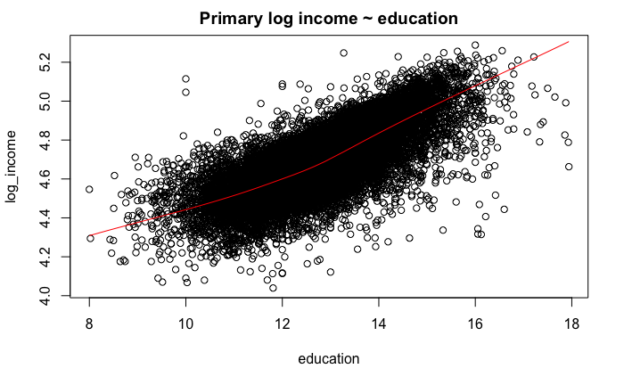

```r
plot(df$log_income ~ df$education,
     ylab="log_income",
     xlab="education",
     main="Primary log income ~ education")
with(df, lines(loess.smooth(education, log_income), col="red"))
```

### Pretty plot

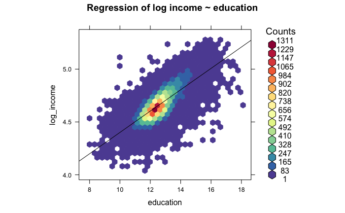

```r
hexbinplot(df$log_income ~ df$education,
           ylab="log_income",
           xlab="education",
           type=c("r"),
           main="Regression of log income ~ education",
           colramp=opacity)
```

`g.` Analyze a detailed summary of a linear regression model between log_income and education. What is the R-squared value? Is the model a good fit? Is it better than the previous model?

```r
model_education <- lm(formula=log_income ~ education, data=df)
summary(model_education)
```

```
Call:
lm(formula = log_income ~ education, data = df)

Residuals:
     Min       1Q   Median       3Q      Max
-0.70515 -0.05355  0.00027  0.05797  0.71386

Coefficients:
             Estimate Std. Error t value Pr(>|t|)
(Intercept) 3.3899508  0.0067222   504.3   <2e-16 ***
education   0.1010778  0.0005319   190.0   <2e-16 ***
---
Signif. codes:  0 ‘***’ 0.001 ‘**’ 0.01 ‘*’ 0.05 ‘.’ 0.1 ‘ ’ 1

Residual standard error: 0.09396 on 31298 degrees of freedom
Multiple R-squared:  0.5357,    Adjusted R-squared:  0.5357
F-statistic: 3.612e+04 on 1 and 31298 DF,  p-value: < 2.2e-16
```

`h.` Analyze a detailed summary of a linear regression model between the dependent variable log_income, and the independent variables age, education, and employment. Is this model a good fit? Why? What conclusions can be made about the different independent variables?

```r
model <- lm(formula=log_income ~ age + education + employment, data=df)
summary(model)
```

```
Call:
lm(formula = log_income ~ age + education + employment, data = df)

Residuals:
     Min       1Q   Median       3Q      Max
-0.78225 -0.04996  0.00073  0.05242  0.83192

Coefficients:
              Estimate Std. Error t value Pr(>|t|)
(Intercept)  3.5166326  0.0076675  458.64   <2e-16 ***
age         -0.0027208  0.0001117  -24.36   <2e-16 ***
education    0.0921118  0.0005981  154.00   <2e-16 ***
employment   0.0601439  0.0019095   31.50   <2e-16 ***
---
Signif. codes:  0 ‘***’ 0.001 ‘**’ 0.01 ‘*’ 0.05 ‘.’ 0.1 ‘ ’ 1

Residual standard error: 0.09064 on 31296 degrees of freedom
Multiple R-squared:  0.5681,    Adjusted R-squared:  0.568
F-statistic: 1.372e+04 on 3 and 31296 DF,  p-value: < 2.2e-16
```

```r
df$predict <- predict(model, select(df, "age", "education", "employment"))
plot(df$predict ~ df$log_income,
     ylab="Predicted data",
     xlab="Training data",
     main="Analyze results model")
with(df, lines(loess.smooth(log_income, predict), col="blue"))
```

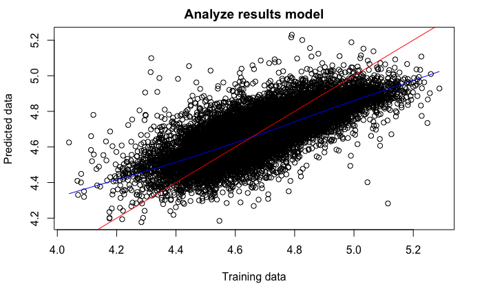

```r
abline(a=0, b=1, col="red")
```

### Pretty plot

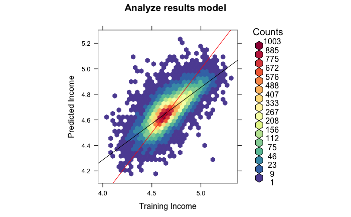

```r
hexbinplot(df$predict ~ df$log_income,
           ylab="Predicted Income",
           xlab="Training Income",
           trans=sqrt,
           inv=function(x) x^2,
           type=c("r"),
           main="Analyze results model",
           panel=function(x, y, ...) {
             panel.hexbinplot(x, y, ...)
             lattice::panel.abline(a = 0, b = 1, col="red")
           },
           colramp=opacity)
```

### Trend of age + education + employment for linear model

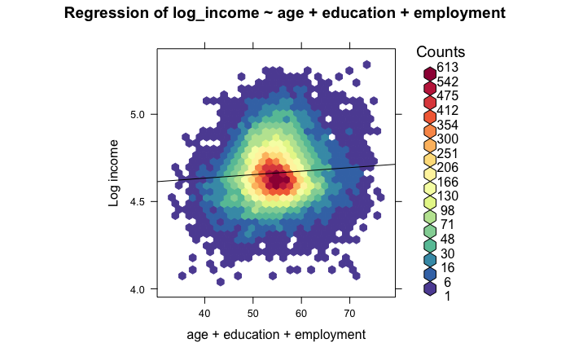

```r
for (i in 1:nrow(df)) {
  df[i, "age_education_employment"] <- sum(df[i, "age"],
                                          df[i, "education"],
                                          df[i, "employment"])
}
hexbinplot(df$log_income ~ df$age_education_employment,
           ylab="Log income",
           xlab="age + education + employment",
           trans=sqrt,
           inv=function(x) x^2,
           type=c("r"),
           main="Regression of log_income ~ age + education + employment",
           colramp=opacity)
```

### Primary data trend

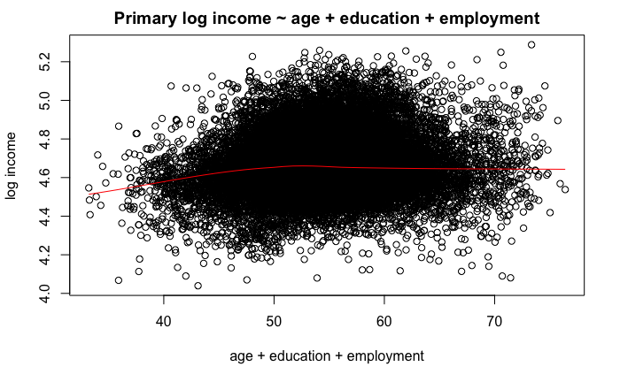

```r
plot(log_income ~ age_education_employment,
     data=df,
     xlab="age + education + employment",
     ylab="log income",
     main="Primary log income ~ age + education + employment",
     col="black"
)
with(df, lines(loess.smooth(age_education_employment, log_income), col="red"))
```

### Corelasion between

```r
cor(df$log_income, df$age_education_employment)
```

```
[1] 0.0724727
```

### Try create more interesting

```r
best_model <- lm(formula=log_income ~ education + employment, data=df)
summary(best_model)
```

```
Call:
lm(formula = log_income ~ education + employment, data = df)

Residuals:
     Min       1Q   Median       3Q      Max
-0.76006 -0.05187 -0.00055  0.05312  0.80409

Coefficients:
             Estimate Std. Error t value Pr(>|t|)
(Intercept) 3.4183229  0.0065809  519.43   <2e-16 ***
education   0.0892176  0.0005917  150.78   <2e-16 ***
employment  0.0754242  0.0018205   41.43   <2e-16 ***
---
Signif. codes:  0 ‘***’ 0.001 ‘**’ 0.01 ‘*’ 0.05 ‘.’ 0.1 ‘ ’ 1

Residual standard error: 0.09149 on 31297 degrees of freedom
Multiple R-squared:  0.5599,    Adjusted R-squared:  0.5598
F-statistic: 1.991e+04 on 2 and 31297 DF,  p-value: < 2.2e-16
```

### Primary data

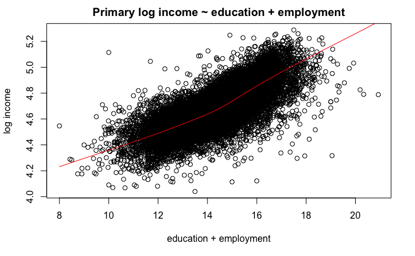

```r
for (i in 1:nrow(df)) {
  df[i, "education_employment"] <- sum(df[i, "education"],
                                       df[i, "employment"])
}
plot(log_income ~ education_employment,
     data=df,
     xlab="education + employment",
     ylab="log income",
     main="Primary log income ~ education + employment",
     col="black"
)
with(df, lines(loess.smooth(education_employment, log_income), col="red"))
```

### Regression of log income ~ education + employment

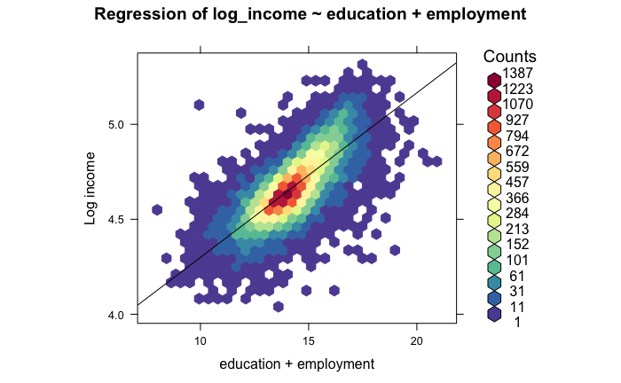

```r
hexbinplot(df$log_income ~ df$education_employment,
           ylab="Log income",
           xlab="education + employment",
           trans=sqrt,
           inv=function(x) x^2,
           type=c("r"),
           main="Regression of log_income ~ education + employment",
           colramp=opacity)
```

### Accuracy model

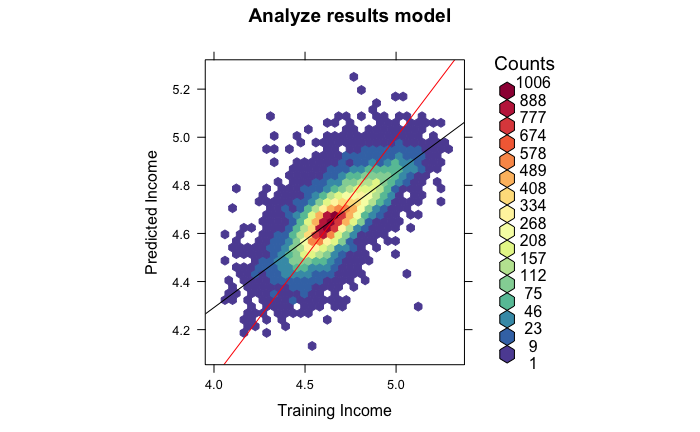

```r
df$best_predict <- predict(best_model, select(df, "education", "employment"))

hexbinplot(df$best_predict ~ df$log_income,
           ylab="Predicted Income",
           xlab="Training Income",
           trans=sqrt,
           inv=function(x) x^2,
           type=c("r"),
           main="Analyze results model",
           panel=function(x, y, ...) {
             panel.hexbinplot(x, y, ...)
             lattice::panel.abline(a = 0, b = 1, col="red")
           },
           colramp=opacity)
```

```r
plot(df$best_predict ~ df$log_income,
     ylab="Predicted data",
     xlab="Training data",
     main="Analyze results model")
with(df, lines(loess.smooth(log_income, best_predict), col="blue"))
```

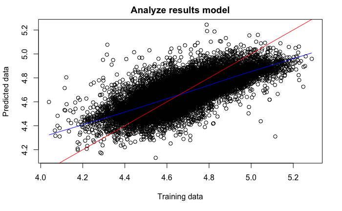

```r
abline(a=0, b=1, col="red")
```

```r
AIC(model)
```

```
[1] -61464.9
```

```r
AIC(best_model)
```

```
[1] -60878.98
```